# Risk Factor Analysis

## Outcome Variable

**Outcome Variable:** wast_rec90d

## Predictor Variables

**Intervention Variable:** predexfd6

**Adjustment Set:**

- arm
- sex
- W_mage
- meducyrs
- feducyrs
- hhwealth_quart
- hfoodsec
- W_mhtcm
- vagbrth
- W_gagebrth
- W_birthwt
- W_birthlen
- W_nrooms
- W_nchldlt5
- month
- brthmon
- W_parity
- impfloor
- impsan
- safeh20
- delta_W_mage
- delta_meducyrs
- delta_feducyrs
- delta_hhwealth_quart
- delta_hfoodsec
- delta_W_mhtcm
- delta_vagbrth
- delta_W_gagebrth
- delta_W_birthwt
- delta_W_birthlen
- delta_W_nrooms
- delta_W_nchldlt5
- delta_month
- delta_brthmon
- delta_W_parity
- delta_impfloor
- delta_impsan
- delta_safeh20

## Stratifying Variables

The analysis was stratified on these variable(s):

- agecat
- studyid
- country

## Data Summary

| agecat | studyid | country | predexfd6 | wast_rec90d | n_cell | n |
| --- | --- | --- | --- | --- | --- | --- |
| 0-24 months | ki0047075b-MAL-ED | BANGLADESH | 1 | 0 | 26 | 121 |
| 0-24 months | ki0047075b-MAL-ED | BANGLADESH | 1 | 1 | 42 | 121 |
| 0-24 months | ki0047075b-MAL-ED | BANGLADESH | 0 | 0 | 18 | 121 |
| 0-24 months | ki0047075b-MAL-ED | BANGLADESH | 0 | 1 | 35 | 121 |
| 0-24 months | ki0047075b-MAL-ED | BRAZIL | 1 | 0 | 1 | 23 |
| 0-24 months | ki0047075b-MAL-ED | BRAZIL | 1 | 1 | 0 | 23 |
| 0-24 months | ki0047075b-MAL-ED | BRAZIL | 0 | 0 | 5 | 23 |
| 0-24 months | ki0047075b-MAL-ED | BRAZIL | 0 | 1 | 17 | 23 |
| 0-24 months | ki0047075b-MAL-ED | INDIA | 1 | 0 | 2 | 170 |
| 0-24 months | ki0047075b-MAL-ED | INDIA | 1 | 1 | 7 | 170 |
| 0-24 months | ki0047075b-MAL-ED | INDIA | 0 | 0 | 64 | 170 |
| 0-24 months | ki0047075b-MAL-ED | INDIA | 0 | 1 | 97 | 170 |
| 0-24 months | ki0047075b-MAL-ED | NEPAL | 1 | 0 | 1 | 90 |
| 0-24 months | ki0047075b-MAL-ED | NEPAL | 1 | 1 | 4 | 90 |
| 0-24 months | ki0047075b-MAL-ED | NEPAL | 0 | 0 | 17 | 90 |
| 0-24 months | ki0047075b-MAL-ED | NEPAL | 0 | 1 | 68 | 90 |
| 0-24 months | ki0047075b-MAL-ED | PERU | 1 | 0 | 1 | 29 |
| 0-24 months | ki0047075b-MAL-ED | PERU | 1 | 1 | 5 | 29 |
| 0-24 months | ki0047075b-MAL-ED | PERU | 0 | 0 | 4 | 29 |
| 0-24 months | ki0047075b-MAL-ED | PERU | 0 | 1 | 19 | 29 |
| 0-24 months | ki0047075b-MAL-ED | SOUTH AFRICA | 1 | 0 | 0 | 77 |
| 0-24 months | ki0047075b-MAL-ED | SOUTH AFRICA | 1 | 1 | 0 | 77 |
| 0-24 months | ki0047075b-MAL-ED | SOUTH AFRICA | 0 | 0 | 12 | 77 |
| 0-24 months | ki0047075b-MAL-ED | SOUTH AFRICA | 0 | 1 | 65 | 77 |
| 0-24 months | ki0047075b-MAL-ED | TANZANIA, UNITED REPUBLIC OF | 1 | 0 | 0 | 45 |
| 0-24 months | ki0047075b-MAL-ED | TANZANIA, UNITED REPUBLIC OF | 1 | 1 | 0 | 45 |
| 0-24 months | ki0047075b-MAL-ED | TANZANIA, UNITED REPUBLIC OF | 0 | 0 | 8 | 45 |
| 0-24 months | ki0047075b-MAL-ED | TANZANIA, UNITED REPUBLIC OF | 0 | 1 | 37 | 45 |
| 0-24 months | ki1000108-CMC-V-BCS-2002 | INDIA | 1 | 0 | 7 | 16 |
| 0-24 months | ki1000108-CMC-V-BCS-2002 | INDIA | 1 | 1 | 9 | 16 |

[output cut: 186 more lines]

The following strata were considered:

- agecat: 0-24 months, studyid: ki0047075b-MAL-ED, country: BANGLADESH
- agecat: 0-24 months, studyid: ki0047075b-MAL-ED, country: BRAZIL
- agecat: 0-24 months, studyid: ki0047075b-MAL-ED, country: INDIA
- agecat: 0-24 months, studyid: ki0047075b-MAL-ED, country: NEPAL
- agecat: 0-24 months, studyid: ki0047075b-MAL-ED, country: PERU
- agecat: 0-24 months, studyid: ki0047075b-MAL-ED, country: SOUTH AFRICA
- agecat: 0-24 months, studyid: ki0047075b-MAL-ED, country: TANZANIA, UNITED REPUBLIC OF
- agecat: 0-24 months, studyid: ki1000108-CMC-V-BCS-2002, country: INDIA
- agecat: 0-24 months, studyid: ki1000108-IRC, country: INDIA
- agecat: 0-24 months, studyid: ki1000109-EE, country: PAKISTAN
- agecat: 0-24 months, studyid: ki1000304b-SAS-CompFeed, country: INDIA
- agecat: 0-24 months, studyid: ki1000304b-SAS-FoodSuppl, country: INDIA
- agecat: 0-24 months, studyid: ki1017093b-PROVIDE, country: BANGLADESH
- agecat: 0-24 months, studyid: ki1101329-Keneba, country: GAMBIA
- agecat: 0-24 months, studyid: ki1113344-GMS-Nepal, country: NEPAL
- agecat: 0-24 months, studyid: ki1148112-LCNI-5, country: MALAWI
- agecat: 0-24 months, studyid: kiGH5241-JiVitA-3, country: BANGLADESH
- agecat: 0-24 months, studyid: kiGH5241-JiVitA-4, country: BANGLADESH
- agecat: 0-6 months, studyid: ki0047075b-MAL-ED, country: BANGLADESH
- agecat: 0-6 months, studyid: ki0047075b-MAL-ED, country: BRAZIL
- agecat: 0-6 months, studyid: ki0047075b-MAL-ED, country: INDIA
- agecat: 0-6 months, studyid: ki0047075b-MAL-ED, country: NEPAL
- agecat: 0-6 months, studyid: ki0047075b-MAL-ED, country: PERU
- agecat: 0-6 months, studyid: ki0047075b-MAL-ED, country: SOUTH AFRICA
- agecat: 0-6 months, studyid: ki0047075b-MAL-ED, country: TANZANIA, UNITED REPUBLIC OF
- agecat: 0-6 months, studyid: ki1000108-CMC-V-BCS-2002, country: INDIA
- agecat: 0-6 months, studyid: ki1000108-IRC, country: INDIA
- agecat: 0-6 months, studyid: ki1000109-EE, country: PAKISTAN
- agecat: 0-6 months, studyid: ki1000304b-SAS-CompFeed, country: INDIA
- agecat: 0-6 months, studyid: ki1000304b-SAS-FoodSuppl, country: INDIA
- agecat: 0-6 months, studyid: ki1017093b-PROVIDE, country: BANGLADESH
- agecat: 0-6 months, studyid: ki1101329-Keneba, country: GAMBIA
- agecat: 0-6 months, studyid: ki1113344-GMS-Nepal, country: NEPAL
- agecat: 0-6 months, studyid: ki1148112-LCNI-5, country: MALAWI
- agecat: 0-6 months, studyid: kiGH5241-JiVitA-3, country: BANGLADESH
- agecat: 0-6 months, studyid: kiGH5241-JiVitA-4, country: BANGLADESH
- agecat: 6-24 months, studyid: ki0047075b-MAL-ED, country: BANGLADESH
- agecat: 6-24 months, studyid: ki0047075b-MAL-ED, country: BRAZIL
- agecat: 6-24 months, studyid: ki0047075b-MAL-ED, country: INDIA
- agecat: 6-24 months, studyid: ki0047075b-MAL-ED, country: NEPAL
- agecat: 6-24 months, studyid: ki0047075b-MAL-ED, country: PERU
- agecat: 6-24 months, studyid: ki0047075b-MAL-ED, country: SOUTH AFRICA
- agecat: 6-24 months, studyid: ki0047075b-MAL-ED, country: TANZANIA, UNITED REPUBLIC OF
- agecat: 6-24 months, studyid: ki1000108-CMC-V-BCS-2002, country: INDIA
- agecat: 6-24 months, studyid: ki1000108-IRC, country: INDIA
- agecat: 6-24 months, studyid: ki1000109-EE, country: PAKISTAN
- agecat: 6-24 months, studyid: ki1000304b-SAS-CompFeed, country: INDIA
- agecat: 6-24 months, studyid: ki1000304b-SAS-FoodSuppl, country: INDIA
- agecat: 6-24 months, studyid: ki1017093b-PROVIDE, country: BANGLADESH
- agecat: 6-24 months, studyid: ki1101329-Keneba, country: GAMBIA
- agecat: 6-24 months, studyid: ki1113344-GMS-Nepal, country: NEPAL
- agecat: 6-24 months, studyid: ki1148112-LCNI-5, country: MALAWI
- agecat: 6-24 months, studyid: kiGH5241-JiVitA-3, country: BANGLADESH
- agecat: 6-24 months, studyid: kiGH5241-JiVitA-4, country: BANGLADESH

### Dropped Strata

Some strata were dropped due to rare outcomes:

- agecat: 0-24 months, studyid: ki0047075b-MAL-ED, country: BRAZIL
- agecat: 0-24 months, studyid: ki0047075b-MAL-ED, country: INDIA
- agecat: 0-24 months, studyid: ki0047075b-MAL-ED, country: NEPAL
- agecat: 0-24 months, studyid: ki0047075b-MAL-ED, country: PERU
- agecat: 0-24 months, studyid: ki0047075b-MAL-ED, country: SOUTH AFRICA
- agecat: 0-24 months, studyid: ki0047075b-MAL-ED, country: TANZANIA, UNITED REPUBLIC OF
- agecat: 0-24 months, studyid: ki1000108-CMC-V-BCS-2002, country: INDIA
- agecat: 0-24 months, studyid: ki1000108-IRC, country: INDIA
- agecat: 0-24 months, studyid: ki1000304b-SAS-FoodSuppl, country: INDIA
- agecat: 0-24 months, studyid: ki1148112-LCNI-5, country: MALAWI
- agecat: 0-6 months, studyid: ki0047075b-MAL-ED, country: BRAZIL
- agecat: 0-6 months, studyid: ki0047075b-MAL-ED, country: INDIA
- agecat: 0-6 months, studyid: ki0047075b-MAL-ED, country: NEPAL
- agecat: 0-6 months, studyid: ki0047075b-MAL-ED, country: PERU
- agecat: 0-6 months, studyid: ki0047075b-MAL-ED, country: SOUTH AFRICA
- agecat: 0-6 months, studyid: ki0047075b-MAL-ED, country: TANZANIA, UNITED REPUBLIC OF
- agecat: 0-6 months, studyid: ki1000108-CMC-V-BCS-2002, country: INDIA
- agecat: 0-6 months, studyid: ki1000108-IRC, country: INDIA
- agecat: 0-6 months, studyid: ki1000304b-SAS-CompFeed, country: INDIA
- agecat: 0-6 months, studyid: ki1000304b-SAS-FoodSuppl, country: INDIA
- agecat: 0-6 months, studyid: ki1148112-LCNI-5, country: MALAWI
- agecat: 6-24 months, studyid: ki0047075b-MAL-ED, country: BRAZIL
- agecat: 6-24 months, studyid: ki0047075b-MAL-ED, country: INDIA
- agecat: 6-24 months, studyid: ki0047075b-MAL-ED, country: NEPAL
- agecat: 6-24 months, studyid: ki0047075b-MAL-ED, country: PERU
- agecat: 6-24 months, studyid: ki0047075b-MAL-ED, country: SOUTH AFRICA
- agecat: 6-24 months, studyid: ki0047075b-MAL-ED, country: TANZANIA, UNITED REPUBLIC OF
- agecat: 6-24 months, studyid: ki1000108-CMC-V-BCS-2002, country: INDIA
- agecat: 6-24 months, studyid: ki1000108-IRC, country: INDIA
- agecat: 6-24 months, studyid: ki1000304b-SAS-CompFeed, country: INDIA
- agecat: 6-24 months, studyid: ki1000304b-SAS-FoodSuppl, country: INDIA
- agecat: 6-24 months, studyid: ki1148112-LCNI-5, country: MALAWI
- agecat: 6-24 months, studyid: kiGH5241-JiVitA-3, country: BANGLADESH

## Methods Detail

We’re interested in the causal parameters $E[Y_a]$ for all values of $a \in \mathcal{A}$. These parameters represent the mean outcome if, possibly contrary to fact, we intervened to set all units to have $A=a$. Under the randomization and positivity assumptions, these are identified by the statistical parameters $\psi_a=E_W[E_{Y|A,W}(Y|A=a,W)]$. In addition, we’re interested in the mean of $Y$, $E[Y]$ under no intervention (the observed mean). We will estimate these parameters by using SuperLearner to fit the relevant likelihood factors – $E_{Y|A,W}(Y|A=a,W)$ and $p(A=a|W)$, and then updating our likelihood fit using a joint TMLE.

For unadjusted analyses ($W=\{\}$), initial likelihoods were estimated using Lrnr_glm to estimate the simple $E(Y|A)$ and Lrnr_mean to estimate $p(A)$. For adjusted analyses, a small library containing Lrnr_glmnet, Lrnr_xgboost, and Lrnr_mean was used.

Having estimated these parameters, we will then use the delta method to estimate relative risks and attributable risks relative to a prespecified baseline level of $A$.

# Results Detail

## Results Plots

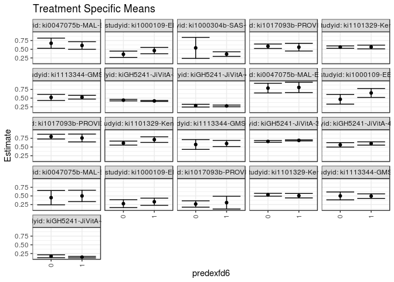

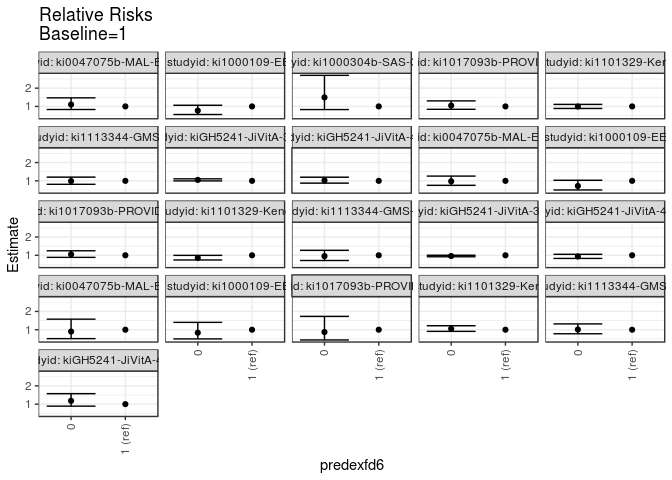

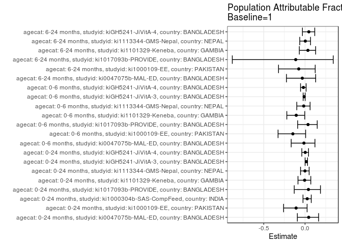

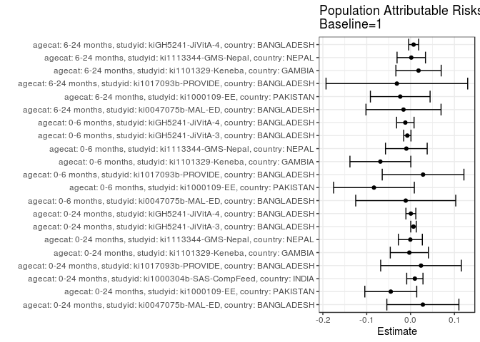

## Results Table

### Parameter: TSM

| agecat | studyid | country | intervention_level | baseline_level | estimate | ci_lower | ci_upper |
| --- | --- | --- | --- | --- | --- | --- | --- |
| 0-24 months | ki0047075b-MAL-ED | BANGLADESH | 1 | NA | 0.6083173 | 0.4985529 | 0.7180818 |
| 0-24 months | ki0047075b-MAL-ED | BANGLADESH | 0 | NA | 0.6723828 | 0.5257456 | 0.8190200 |
| 0-24 months | ki1000109-EE | PAKISTAN | 1 | NA | 0.4614799 | 0.3700928 | 0.5528669 |
| 0-24 months | ki1000109-EE | PAKISTAN | 0 | NA | 0.3555034 | 0.2650314 | 0.4459754 |
| 0-24 months | ki1000304b-SAS-CompFeed | INDIA | 1 | NA | 0.3600000 | 0.2937351 | 0.4262649 |
| 0-24 months | ki1000304b-SAS-CompFeed | INDIA | 0 | NA | 0.5384615 | 0.2364546 | 0.8404685 |
| 0-24 months | ki1017093b-PROVIDE | BANGLADESH | 1 | NA | 0.5592706 | 0.4485504 | 0.6699908 |
| 0-24 months | ki1017093b-PROVIDE | BANGLADESH | 0 | NA | 0.5860764 | 0.5221221 | 0.6500307 |
| 0-24 months | ki1101329-Keneba | GAMBIA | 1 | NA | 0.5639437 | 0.5106676 | 0.6172198 |
| 0-24 months | ki1101329-Keneba | GAMBIA | 0 | NA | 0.5604645 | 0.5260751 | 0.5948539 |
| 0-24 months | ki1113344-GMS-Nepal | NEPAL | 1 | NA | 0.5265746 | 0.4727228 | 0.5804265 |
| 0-24 months | ki1113344-GMS-Nepal | NEPAL | 0 | NA | 0.5204626 | 0.4326780 | 0.6082473 |
| 0-24 months | kiGH5241-JiVitA-3 | BANGLADESH | 1 | NA | 0.4195714 | 0.4068331 | 0.4323096 |
| 0-24 months | kiGH5241-JiVitA-3 | BANGLADESH | 0 | NA | 0.4415678 | 0.4207029 | 0.4624327 |
| 0-24 months | kiGH5241-JiVitA-4 | BANGLADESH | 1 | NA | 0.2760506 | 0.2520472 | 0.3000541 |
| 0-24 months | kiGH5241-JiVitA-4 | BANGLADESH | 0 | NA | 0.2829733 | 0.2434661 | 0.3224806 |
| 0-6 months | ki0047075b-MAL-ED | BANGLADESH | 1 | NA | 0.8076923 | 0.6590088 | 0.9563759 |
| 0-6 months | ki0047075b-MAL-ED | BANGLADESH | 0 | NA | 0.7878788 | 0.6482934 | 0.9274642 |
| 0-6 months | ki1000109-EE | PAKISTAN | 1 | NA | 0.6483068 | 0.5198600 | 0.7767536 |
| 0-6 months | ki1000109-EE | PAKISTAN | 0 | NA | 0.4667120 | 0.3269489 | 0.6064751 |
| 0-6 months | ki1017093b-PROVIDE | BANGLADESH | 1 | NA | 0.7595453 | 0.6472366 | 0.8718541 |
| 0-6 months | ki1017093b-PROVIDE | BANGLADESH | 0 | NA | 0.7991229 | 0.7307628 | 0.8674829 |
| 0-6 months | ki1101329-Keneba | GAMBIA | 1 | NA | 0.7131561 | 0.6320569 | 0.7942554 |
| 0-6 months | ki1101329-Keneba | GAMBIA | 0 | NA | 0.6129395 | 0.5557626 | 0.6701165 |
| 0-6 months | ki1113344-GMS-Nepal | NEPAL | 1 | NA | 0.6003176 | 0.5124680 | 0.6881672 |
| 0-6 months | ki1113344-GMS-Nepal | NEPAL | 0 | NA | 0.5726332 | 0.4314876 | 0.7137788 |
| 0-6 months | kiGH5241-JiVitA-3 | BANGLADESH | 1 | NA | 0.6902463 | 0.6747281 | 0.7057646 |
| 0-6 months | kiGH5241-JiVitA-3 | BANGLADESH | 0 | NA | 0.6614818 | 0.6365738 | 0.6863898 |
| 0-6 months | kiGH5241-JiVitA-4 | BANGLADESH | 1 | NA | 0.6020042 | 0.5549906 | 0.6490178 |
| 0-6 months | kiGH5241-JiVitA-4 | BANGLADESH | 0 | NA | 0.5621271 | 0.4977721 | 0.6264821 |
| 6-24 months | ki0047075b-MAL-ED | BANGLADESH | 1 | NA | 0.5000000 | 0.3367001 | 0.6632999 |
| 6-24 months | ki0047075b-MAL-ED | BANGLADESH | 0 | NA | 0.4500000 | 0.2444054 | 0.6555946 |
| 6-24 months | ki1000109-EE | PAKISTAN | 1 | NA | 0.3323053 | 0.2292897 | 0.4353209 |
| 6-24 months | ki1000109-EE | PAKISTAN | 0 | NA | 0.2777979 | 0.1641814 | 0.3914144 |
| 6-24 months | ki1017093b-PROVIDE | BANGLADESH | 1 | NA | 0.3076923 | 0.1243207 | 0.4910639 |
| 6-24 months | ki1017093b-PROVIDE | BANGLADESH | 0 | NA | 0.2680412 | 0.1773699 | 0.3587126 |
| 6-24 months | ki1101329-Keneba | GAMBIA | 1 | NA | 0.5067563 | 0.4429225 | 0.5705900 |
| 6-24 months | ki1101329-Keneba | GAMBIA | 0 | NA | 0.5336859 | 0.4930608 | 0.5743110 |
| 6-24 months | ki1113344-GMS-Nepal | NEPAL | 1 | NA | 0.4943570 | 0.4291188 | 0.5595953 |
| 6-24 months | ki1113344-GMS-Nepal | NEPAL | 0 | NA | 0.5003040 | 0.3865167 | 0.6140914 |
| 6-24 months | kiGH5241-JiVitA-4 | BANGLADESH | 1 | NA | 0.1452378 | 0.1237592 | 0.1667164 |
| 6-24 months | kiGH5241-JiVitA-4 | BANGLADESH | 0 | NA | 0.1718756 | 0.1300205 | 0.2137308 |

### Parameter: E(Y)

| agecat | studyid | country | intervention_level | baseline_level | estimate | ci_lower | ci_upper |
| --- | --- | --- | --- | --- | --- | --- | --- |
| 0-24 months | ki0047075b-MAL-ED | BANGLADESH | NA | NA | 0.6363636 | 0.5494154 | 0.7233119 |
| 0-24 months | ki1000109-EE | PAKISTAN | NA | NA | 0.4163424 | 0.3511349 | 0.4815500 |
| 0-24 months | ki1000304b-SAS-CompFeed | INDIA | NA | NA | 0.3697479 | 0.3045176 | 0.4349782 |
| 0-24 months | ki1017093b-PROVIDE | BANGLADESH | NA | NA | 0.5830619 | 0.5262762 | 0.6398476 |
| 0-24 months | ki1101329-Keneba | GAMBIA | NA | NA | 0.5610860 | 0.5320121 | 0.5901599 |
| 0-24 months | ki1113344-GMS-Nepal | NEPAL | NA | NA | 0.5260223 | 0.4802445 | 0.5718001 |
| 0-24 months | kiGH5241-JiVitA-3 | BANGLADESH | NA | NA | 0.4262098 | 0.4150208 | 0.4373989 |
| 0-24 months | kiGH5241-JiVitA-4 | BANGLADESH | NA | NA | 0.2766885 | 0.2556490 | 0.2977279 |
| 0-6 months | ki0047075b-MAL-ED | BANGLADESH | NA | NA | 0.7966102 | 0.6946250 | 0.8985954 |
| 0-6 months | ki1000109-EE | PAKISTAN | NA | NA | 0.5648148 | 0.4692893 | 0.6603404 |
| 0-6 months | ki1017093b-PROVIDE | BANGLADESH | NA | NA | 0.7880435 | 0.7295878 | 0.8464992 |
| 0-6 months | ki1101329-Keneba | GAMBIA | NA | NA | 0.6442786 | 0.5973688 | 0.6911884 |
| 0-6 months | ki1113344-GMS-Nepal | NEPAL | NA | NA | 0.5906433 | 0.5164645 | 0.6648221 |
| 0-6 months | kiGH5241-JiVitA-3 | BANGLADESH | NA | NA | 0.6828279 | 0.6694976 | 0.6961581 |
| 0-6 months | kiGH5241-JiVitA-4 | BANGLADESH | NA | NA | 0.5900383 | 0.5478064 | 0.6322702 |
| 6-24 months | ki0047075b-MAL-ED | BANGLADESH | NA | NA | 0.4838710 | 0.3544124 | 0.6133295 |
| 6-24 months | ki1000109-EE | PAKISTAN | NA | NA | 0.3087248 | 0.2336906 | 0.3837591 |
| 6-24 months | ki1017093b-PROVIDE | BANGLADESH | NA | NA | 0.2764228 | 0.1950773 | 0.3577682 |
| 6-24 months | ki1101329-Keneba | GAMBIA | NA | NA | 0.5248918 | 0.4904236 | 0.5593599 |
| 6-24 months | ki1113344-GMS-Nepal | NEPAL | NA | NA | 0.4959128 | 0.4403572 | 0.5514684 |
| 6-24 months | kiGH5241-JiVitA-4 | BANGLADESH | NA | NA | 0.1522070 | 0.1331665 | 0.1712475 |

### Parameter: RR

| agecat | studyid | country | intervention_level | baseline_level | estimate | ci_lower | ci_upper |
| --- | --- | --- | --- | --- | --- | --- | --- |
| 0-24 months | ki0047075b-MAL-ED | BANGLADESH | 1 | 1 | 1.0000000 | 1.0000000 | 1.0000000 |
| 0-24 months | ki0047075b-MAL-ED | BANGLADESH | 0 | 1 | 1.1053158 | 0.8314106 | 1.4694582 |
| 0-24 months | ki1000109-EE | PAKISTAN | 1 | 1 | 1.0000000 | 1.0000000 | 1.0000000 |
| 0-24 months | ki1000109-EE | PAKISTAN | 0 | 1 | 0.7703551 | 0.5583877 | 1.0627867 |
| 0-24 months | ki1000304b-SAS-CompFeed | INDIA | 1 | 1 | 1.0000000 | 1.0000000 | 1.0000000 |
| 0-24 months | ki1000304b-SAS-CompFeed | INDIA | 0 | 1 | 1.4957265 | 0.8288715 | 2.6990889 |
| 0-24 months | ki1017093b-PROVIDE | BANGLADESH | 1 | 1 | 1.0000000 | 1.0000000 | 1.0000000 |
| 0-24 months | ki1017093b-PROVIDE | BANGLADESH | 0 | 1 | 1.0479300 | 0.8424668 | 1.3035022 |
| 0-24 months | ki1101329-Keneba | GAMBIA | 1 | 1 | 1.0000000 | 1.0000000 | 1.0000000 |
| 0-24 months | ki1101329-Keneba | GAMBIA | 0 | 1 | 0.9938307 | 0.8886723 | 1.1114326 |
| 0-24 months | ki1113344-GMS-Nepal | NEPAL | 1 | 1 | 1.0000000 | 1.0000000 | 1.0000000 |
| 0-24 months | ki1113344-GMS-Nepal | NEPAL | 0 | 1 | 0.9883930 | 0.8113523 | 1.2040646 |
| 0-24 months | kiGH5241-JiVitA-3 | BANGLADESH | 1 | 1 | 1.0000000 | 1.0000000 | 1.0000000 |
| 0-24 months | kiGH5241-JiVitA-3 | BANGLADESH | 0 | 1 | 1.0524259 | 0.9973932 | 1.1104952 |
| 0-24 months | kiGH5241-JiVitA-4 | BANGLADESH | 1 | 1 | 1.0000000 | 1.0000000 | 1.0000000 |
| 0-24 months | kiGH5241-JiVitA-4 | BANGLADESH | 0 | 1 | 1.0250776 | 0.8753367 | 1.2004342 |
| 0-6 months | ki0047075b-MAL-ED | BANGLADESH | 1 | 1 | 1.0000000 | 1.0000000 | 1.0000000 |
| 0-6 months | ki0047075b-MAL-ED | BANGLADESH | 0 | 1 | 0.9754690 | 0.7555273 | 1.2594379 |
| 0-6 months | ki1000109-EE | PAKISTAN | 1 | 1 | 1.0000000 | 1.0000000 | 1.0000000 |
| 0-6 months | ki1000109-EE | PAKISTAN | 0 | 1 | 0.7198937 | 0.5021219 | 1.0321138 |
| 0-6 months | ki1017093b-PROVIDE | BANGLADESH | 1 | 1 | 1.0000000 | 1.0000000 | 1.0000000 |
| 0-6 months | ki1017093b-PROVIDE | BANGLADESH | 0 | 1 | 1.0521069 | 0.8867135 | 1.2483502 |
| 0-6 months | ki1101329-Keneba | GAMBIA | 1 | 1 | 1.0000000 | 1.0000000 | 1.0000000 |
| 0-6 months | ki1101329-Keneba | GAMBIA | 0 | 1 | 0.8594745 | 0.7426821 | 0.9946335 |
| 0-6 months | ki1113344-GMS-Nepal | NEPAL | 1 | 1 | 1.0000000 | 1.0000000 | 1.0000000 |
| 0-6 months | ki1113344-GMS-Nepal | NEPAL | 0 | 1 | 0.9538837 | 0.7158793 | 1.2710163 |
| 0-6 months | kiGH5241-JiVitA-3 | BANGLADESH | 1 | 1 | 1.0000000 | 1.0000000 | 1.0000000 |
| 0-6 months | kiGH5241-JiVitA-3 | BANGLADESH | 0 | 1 | 0.9583272 | 0.9179892 | 1.0004376 |
| 0-6 months | kiGH5241-JiVitA-4 | BANGLADESH | 1 | 1 | 1.0000000 | 1.0000000 | 1.0000000 |
| 0-6 months | kiGH5241-JiVitA-4 | BANGLADESH | 0 | 1 | 0.9337594 | 0.8278726 | 1.0531893 |
| 6-24 months | ki0047075b-MAL-ED | BANGLADESH | 1 | 1 | 1.0000000 | 1.0000000 | 1.0000000 |
| 6-24 months | ki0047075b-MAL-ED | BANGLADESH | 0 | 1 | 0.9000000 | 0.5131644 | 1.5784417 |
| 6-24 months | ki1000109-EE | PAKISTAN | 1 | 1 | 1.0000000 | 1.0000000 | 1.0000000 |
| 6-24 months | ki1000109-EE | PAKISTAN | 0 | 1 | 0.8359719 | 0.4982307 | 1.4026615 |
| 6-24 months | ki1017093b-PROVIDE | BANGLADESH | 1 | 1 | 1.0000000 | 1.0000000 | 1.0000000 |
| 6-24 months | ki1017093b-PROVIDE | BANGLADESH | 0 | 1 | 0.8711340 | 0.4389733 | 1.7287486 |
| 6-24 months | ki1101329-Keneba | GAMBIA | 1 | 1 | 1.0000000 | 1.0000000 | 1.0000000 |
| 6-24 months | ki1101329-Keneba | GAMBIA | 0 | 1 | 1.0531412 | 0.9101683 | 1.2185728 |
| 6-24 months | ki1113344-GMS-Nepal | NEPAL | 1 | 1 | 1.0000000 | 1.0000000 | 1.0000000 |
| 6-24 months | ki1113344-GMS-Nepal | NEPAL | 0 | 1 | 1.0120298 | 0.7774738 | 1.3173489 |
| 6-24 months | kiGH5241-JiVitA-4 | BANGLADESH | 1 | 1 | 1.0000000 | 1.0000000 | 1.0000000 |
| 6-24 months | kiGH5241-JiVitA-4 | BANGLADESH | 0 | 1 | 1.1834085 | 0.8899775 | 1.5735854 |

### Parameter: PAR

| agecat | studyid | country | intervention_level | baseline_level | estimate | ci_lower | ci_upper |
| --- | --- | --- | --- | --- | --- | --- | --- |
| 0-24 months | ki0047075b-MAL-ED | BANGLADESH | 1 | NA | 0.0280463 | -0.0540977 | 0.1101903 |
| 0-24 months | ki1000109-EE | PAKISTAN | 1 | NA | -0.0451375 | -0.1043553 | 0.0140803 |
| 0-24 months | ki1000304b-SAS-CompFeed | INDIA | 1 | NA | 0.0097479 | -0.0087899 | 0.0282857 |
| 0-24 months | ki1017093b-PROVIDE | BANGLADESH | 1 | NA | 0.0237913 | -0.0681982 | 0.1157808 |
| 0-24 months | ki1101329-Keneba | GAMBIA | 1 | NA | -0.0028577 | -0.0463023 | 0.0405869 |
| 0-24 months | ki1113344-GMS-Nepal | NEPAL | 1 | NA | -0.0005523 | -0.0279119 | 0.0268072 |
| 0-24 months | kiGH5241-JiVitA-3 | BANGLADESH | 1 | NA | 0.0066385 | 0.0003727 | 0.0129042 |
| 0-24 months | kiGH5241-JiVitA-4 | BANGLADESH | 1 | NA | 0.0006378 | -0.0106377 | 0.0119133 |
| 0-6 months | ki0047075b-MAL-ED | BANGLADESH | 1 | NA | -0.0110821 | -0.1251307 | 0.1029664 |
| 0-6 months | ki1000109-EE | PAKISTAN | 1 | NA | -0.0834920 | -0.1755242 | 0.0085403 |
| 0-6 months | ki1017093b-PROVIDE | BANGLADESH | 1 | NA | 0.0284982 | -0.0646677 | 0.1216640 |
| 0-6 months | ki1101329-Keneba | GAMBIA | 1 | NA | -0.0688775 | -0.1382685 | 0.0005134 |
| 0-6 months | ki1113344-GMS-Nepal | NEPAL | 1 | NA | -0.0096743 | -0.0572183 | 0.0378697 |
| 0-6 months | kiGH5241-JiVitA-3 | BANGLADESH | 1 | NA | -0.0074185 | -0.0157309 | 0.0008940 |
| 0-6 months | kiGH5241-JiVitA-4 | BANGLADESH | 1 | NA | -0.0119659 | -0.0318680 | 0.0079363 |
| 6-24 months | ki0047075b-MAL-ED | BANGLADESH | 1 | NA | -0.0161290 | -0.1017291 | 0.0694710 |
| 6-24 months | ki1000109-EE | PAKISTAN | 1 | NA | -0.0235805 | -0.0916436 | 0.0444827 |
| 6-24 months | ki1017093b-PROVIDE | BANGLADESH | 1 | NA | -0.0312695 | -0.1927776 | 0.1302386 |
| 6-24 months | ki1101329-Keneba | GAMBIA | 1 | NA | 0.0181355 | -0.0335121 | 0.0697831 |
| 6-24 months | ki1113344-GMS-Nepal | NEPAL | 1 | NA | 0.0015558 | -0.0308540 | 0.0339656 |
| 6-24 months | kiGH5241-JiVitA-4 | BANGLADESH | 1 | NA | 0.0069692 | -0.0043926 | 0.0183310 |

### Parameter: PAF

| agecat | studyid | country | intervention_level | baseline_level | estimate | ci_lower | ci_upper |
| --- | --- | --- | --- | --- | --- | --- | --- |
| 0-24 months | ki0047075b-MAL-ED | BANGLADESH | 1 | NA | 0.0440727 | -0.0932001 | 0.1641082 |
| 0-24 months | ki1000109-EE | PAKISTAN | 1 | NA | -0.1084143 | -0.2598468 | 0.0248162 |
| 0-24 months | ki1000304b-SAS-CompFeed | INDIA | 1 | NA | 0.0263636 | -0.0248925 | 0.0750564 |
| 0-24 months | ki1017093b-PROVIDE | BANGLADESH | 1 | NA | 0.0408041 | -0.1309977 | 0.1865087 |
| 0-24 months | ki1101329-Keneba | GAMBIA | 1 | NA | -0.0050931 | -0.0855717 | 0.0694192 |
| 0-24 months | ki1113344-GMS-Nepal | NEPAL | 1 | NA | -0.0010500 | -0.0544350 | 0.0496322 |
| 0-24 months | kiGH5241-JiVitA-3 | BANGLADESH | 1 | NA | 0.0155755 | 0.0007649 | 0.0301666 |
| 0-24 months | kiGH5241-JiVitA-4 | BANGLADESH | 1 | NA | 0.0023051 | -0.0392929 | 0.0422382 |
| 0-6 months | ki0047075b-MAL-ED | BANGLADESH | 1 | NA | -0.0139116 | -0.1678073 | 0.1197034 |
| 0-6 months | ki1000109-EE | PAKISTAN | 1 | NA | -0.1478218 | -0.3268682 | 0.0070642 |
| 0-6 months | ki1017093b-PROVIDE | BANGLADESH | 1 | NA | 0.0361632 | -0.0897956 | 0.1475636 |
| 0-6 months | ki1101329-Keneba | GAMBIA | 1 | NA | -0.1069064 | -0.2209088 | -0.0035491 |
| 0-6 months | ki1113344-GMS-Nepal | NEPAL | 1 | NA | -0.0163793 | -0.1001907 | 0.0610474 |
| 0-6 months | kiGH5241-JiVitA-3 | BANGLADESH | 1 | NA | -0.0108643 | -0.0231191 | 0.0012437 |
| 0-6 months | kiGH5241-JiVitA-4 | BANGLADESH | 1 | NA | -0.0202799 | -0.0545788 | 0.0129036 |
| 6-24 months | ki0047075b-MAL-ED | BANGLADESH | 1 | NA | -0.0333333 | -0.2253187 | 0.1285714 |
| 6-24 months | ki1000109-EE | PAKISTAN | 1 | NA | -0.0763802 | -0.3212271 | 0.1230921 |
| 6-24 months | ki1017093b-PROVIDE | BANGLADESH | 1 | NA | -0.1131222 | -0.8811275 | 0.3413307 |
| 6-24 months | ki1101329-Keneba | GAMBIA | 1 | NA | 0.0345509 | -0.0692182 | 0.1282491 |
| 6-24 months | ki1113344-GMS-Nepal | NEPAL | 1 | NA | 0.0031372 | -0.0644200 | 0.0664065 |
| 6-24 months | kiGH5241-JiVitA-4 | BANGLADESH | 1 | NA | 0.0457877 | -0.0316603 | 0.1174217 |